# Fuzzy Matching

Pedram Roshdinavid

August 30, 2016

From David Doherty: https://connect.fg.rbc.com/message/587343#587343

I have a database of athletes for triathlons with all their results stored in them covering the last few years I will get lists of athletes for future events and I want to cross compare them, however some of the fields are not normalised

E.g. the names may not be expressed the same way ‘John Smith’ may be ‘Smith, John’ or ‘John J. Smith’. I want to employ fuzzy matching to cross compare them. In Excel this is horrific as I have to find and install an add-in and then once I email the sheet to someone, either the sheet doesn’t work or they have to also install the add-in

There are additional helper columns to avoid mistmatches: e.g. you can identify their age group; and; in previous results you are given their home town and country, and in the future list you are given their state.

Once I’ve managed to cross-compare the results I want to run stuff like: For everyone aged 25-29 in an upcoming event, show me their results where available, and order them by finishing time From the data below you should be able to see that ‘Tom Aaker’ is doing an upcoming race, and this is the same guy that is listed as ‘Thomas Aaker’ in a previous result.

Eventually after that you may want to run additional more advanced analytics: Normalise results for difficulty (e.g. by using the winners time as a scaling mechanism for previous results) Run simulations to figure out if athletes perform comparitively better on certain types of courses

Example data, results from previous races:

Name State Country Gender Division Overall Alicia Kaye Clermont USA Female FPRO 4:27:39 Ryan Ung Los Angeles USA Male M25-29 4:30:40 Lauren Barnett Plano USA Female FPRO 4:31:00 Aaron Church South Riding USA Male M40-44 4:31:43 Anthony Chan Flushing USA Male M18-24 4:35:03 Dan Stephens Boise USA Male M50-54 4:35:16 Thomas Aaker San Francisco USA Male M25-29 4:36:57 Jacob Slife West Point USA Male M18-24 4:37:43 Matt Smith Denver USA Male M35-39 4:38:07 Bill Picciano Jupiter USA Male M45-49 4:39:50 Steve Chaid Wien USA Male M45-49 4:39:58

Example for name for upcoming races

Name Age group State Tom Aaker M25-29 CA James Aaron M35-39 AL Dave Abel M45-49 DC Robert Abernathy M45-49 GA Richard Abrahamson M35-39 MN Sidney Abramson M25-29 KY Filip Achten M30-34 NY Luis Acuna M30-34 IL Elizabeth Acuna F30-34 IL Jennifer Adamo F40-44 IN

# Fuzzy Matching

This might be the more difficult part of this job, but not impossible. First, let’s import some data from the web

```r
library(readxl)
library(dplyr)
tri <- read_excel("practical_examples/itu-world-triathlon-series-male.xls")
```

[output not shown]

```r
head(tri)
```

```
## # A tibble: 6 × 16
##   Ranking `Prior Ranking`    Change `First Name` `Last Name` Country   YOB
##     <dbl>           <dbl>     <chr>        <chr>       <chr>   <chr> <dbl>
## 1       1               2  1.000000        Mario        Mola     ESP  1990
## 2       2               1 -1.000000     Fernando      Alarza     ESP  1991
## 3       3               3  0.000000     Jonathan    Brownlee     GBR  1990
## 4       4               4  0.000000       Pierre    Le Corre     FRA  1990
## 5       5              12  7.000000        Jacob Birtwhistle     AUS  1995
## 6       6              10  4.000000         Ryan      Bailie     AUS  1990
## # ... with 9 more variables: `Total Events` <dbl>, `World Cups` <dbl>,
## #   Points <dbl>, `Final Score` <dbl>, `Current Best Score` <dbl>,
## #   `Current 2nd Score` <dbl>, `Current 3rd Score` <dbl>, `Current 4th
## #   Score` <dbl>, `Current 5th Score` <dbl>
```

Now, let’s create a full name field

```r
tri <- tri %>%
  mutate(full_name = paste(`First Name`, `Last Name`))

head(tri[,c(4,5,17)])
```

```
## # A tibble: 6 × 3
##   `First Name` `Last Name`         full_name
##          <chr>       <chr>             <chr>
## 1        Mario        Mola        Mario Mola
## 2     Fernando      Alarza   Fernando Alarza
## 3     Jonathan    Brownlee Jonathan Brownlee
## 4       Pierre    Le Corre   Pierre Le Corre
## 5        Jacob Birtwhistle Jacob Birtwhistle
## 6         Ryan      Bailie       Ryan Bailie
```

Now let’s create a fake name and see if we can match it

```r
fns <- c('Mario Molla', "Molla, Mario", "Mola, Mario", "Mario Mola Jr.", "Catherine Great", "John Travolta")
rn <- 'Mario Mola'

library(stringdist)
stringdist(fns, rn) # Default method
```

```
## [1]  1  9  8  4 10 10
```

```r
stringdist(fns, rn, method = 'qgram') # Seems to work better for our examples
```

```
## [1]  1  2  1  4 15  9
```

Now that we have a method, let’s create a name and find the best match in our dataset

```r
m <- stringdist('Pedram Navid', tri$full_name, method = 'qgram')
m
```

```
##  [1] 12 15 19 17 19 13 14 18 17 11 19 18 16 17 17 15 20 17 15 13 10 13 17
## [24] 21 12 15 17 22 15 13 19 16 14 17 14 16 11 15 13 18 19 15 16 17 12 19
## [47] 12 19 22 20 18 14 16 16 14 15 16 19 15 18 13 15 19 21 21 17 14 18 17
## [70] 17 18 17 17 15 21 18 16 19 13 13 17 15 17 15 21 13 15 15 13 19 18 14
## [93] 18 16 16  8 13 14 18
```

```r
min(m)
```

```
## [1] 8
```

```r
# Best match is a 8. Let's find it
which.min(m)
```

```
## [1] 96
```

```r
# 96th one!
tri$full_name[96]
```

```
## [1] "Sam Ward"
```

```r
# Not very close. Let's try another name
m <- stringdist('Greg Billington', tri$full_name, 'qgram')
min(m)
```

```
## [1] 3
```

```r
which.min(m)
```

```
## [1] 49
```

```r
tri$full_name[49]
```

```
## [1] "Gregory Billington"
```

```r
# Pretty good! So, what threshold do we use?
methods <- c('osa', 'lv', 'dl', 'hamming' , 'lcs', 'qgram', 'cosine', 'jaccard', 'jw')
for(i in methods) {
  m <- stringdist('Billington, Greg', tri$full_name, method =  i)
  print(paste("Method:", i, tri$full_name[which.min(m)]))
}
```

```
## [1] "Method: osa Irving Perez"
## [1] "Method: lv Irving Perez"
## [1] "Method: dl Irving Perez"
## [1] "Method: hamming Tyler Mislawchuk"
## [1] "Method: lcs Gregory Billington"
## [1] "Method: qgram Gregory Billington"
## [1] "Method: cosine Gregory Billington"
## [1] "Method: jaccard Gregory Billington"
## [1] "Method: jw Gregory Billington"
```

```r
# make a function to find the best method for a given name

find_best <- function(name) {
  methods <- c('osa', 'lv', 'dl', 'hamming' , 'lcs', 'qgram', 'cosine', 'jaccard', 'jw')
  for(i in methods) {
    m <- stringdist(name, tri$full_name, method =  i)
    cat(paste0(i, "\t  ", tri$full_name[which.min(m)], "\t", round(min(m), 2)))
    cat('\n')
  }
}
find_best("Sissons Jr., Ryan")
```

```
## osa    Simon Viain   11
## lv     Simon Viain   11
## dl     Simon Viain   11
## hamming    Alessandro Fabian 14
## lcs    Simon Viain   14
## qgram      Ryan Sissons  5
## cosine     Ryan Sissons  0.1
## jaccard    Ryan Sissons  0.31
## jw     Simon Viain   0.32
```

```r
find_best("Donald Alfredon")
```

```
## osa    Ron Darmon    9
## lv     Ron Darmon    9
## dl     Ron Darmon    9
## hamming    Danilo Pimentel   11
## lcs    Ron Darmon    13
## qgram      Aaron Royle   8
## cosine     Aaron Royle   0.25
## jaccard    Fernando Alarza   0.31
## jw     Ron Darmon    0.33
```

```r
find_best("Aron Roile")
```

```
## osa    Aaron Royle   2
## lv     Aaron Royle   2
## dl     Aaron Royle   2
## hamming    Kyle Jones    8
## lcs    Aaron Royle   3
## qgram      Aaron Royle   3
## cosine     Aaron Royle   0.12
## jaccard    Aaron Royle   0.27
## jw     Aaron Royle   0.09
```

```r
find_best("Matt Sharpe")
```

```
## osa    Matthew Sharp 4
## lv     Matthew Sharp 4
## dl     Matthew Sharp 4
## hamming    Ryan Bailie   9
## lcs    Matthew Sharp 4
## qgram      Matthew Sharp 2
## cosine     Matthew Sharp 0.05
## jaccard    Matthew Sharp 0.1
## jw     Matthew Sharp 0.16
```

# Analysis of results

For everyone aged 25-29 in an upcoming event, show me their results where available, and order them by finishing time

```r
library(ggplot2)
# create approx. age column and get rid of unneeded columns
tri_small <- tri %>%
  mutate(age = 2016 - YOB) %>%
  select(rank = Ranking, full_name, country = Country, age, events = `Total Events`,
    wcups = `World Cups`, points = Points, best_score = `Current Best Score`)
head(tri_small)
```

```
## # A tibble: 6 × 8
##    rank         full_name country   age events wcups points best_score
##   <dbl>             <chr>   <chr> <dbl>  <dbl> <dbl>  <dbl>      <dbl>
## 1     1        Mario Mola     ESP    26      5     0   3833     800.00
## 2     2   Fernando Alarza     ESP    25      5     0   3443     800.00
## 3     3 Jonathan Brownlee     GBR    26      4     0   2905     740.00
## 4     4   Pierre Le Corre     FRA    26      4     0   2354     684.50
## 5     5 Jacob Birtwhistle     AUS    21      5     0   2165     740.00
## 6     6       Ryan Bailie     AUS    26      4     0   2079     633.16
```

```r
tri_small %>%
  filter(age>=25, age<=29) %>%
  top_n(5, best_score)
```

```
## # A tibble: 6 × 8
##    rank         full_name country   age events wcups points best_score
##   <dbl>             <chr>   <chr> <dbl>  <dbl> <dbl>  <dbl>      <dbl>
## 1     1        Mario Mola     ESP    26      5     0   3833        800
## 2     2   Fernando Alarza     ESP    25      5     0   3443        800
## 3     3 Jonathan Brownlee     GBR    26      4     0   2905        740
## 4     9 Crisanto Grajales     MEX    29      4     0   1888        740
## 5    11 Alistair Brownlee     GBR    28      3     0   1652        800
## 6    33    Richard Murray     RSA    27      1     0    740        740
```

```r
tri_small %>%
  filter(age>=35) %>%
  top_n(5, points)
```

```
## # A tibble: 4 × 8
##    rank         full_name country   age events wcups points best_score
##   <dbl>             <chr>   <chr> <dbl>  <dbl> <dbl>  <dbl>      <dbl>
## 1    39       Bryan Keane     IRL    36      4     0    576     212.57
## 2    75 Courtney Atkinson     AUS    37      2     0    167      90.17
## 3    78     Sven Riederer     SUI    35      1     0    123     123.17
## 4    93  Hirokatsu Tayama     JPN    35      1     0     45      44.70
```

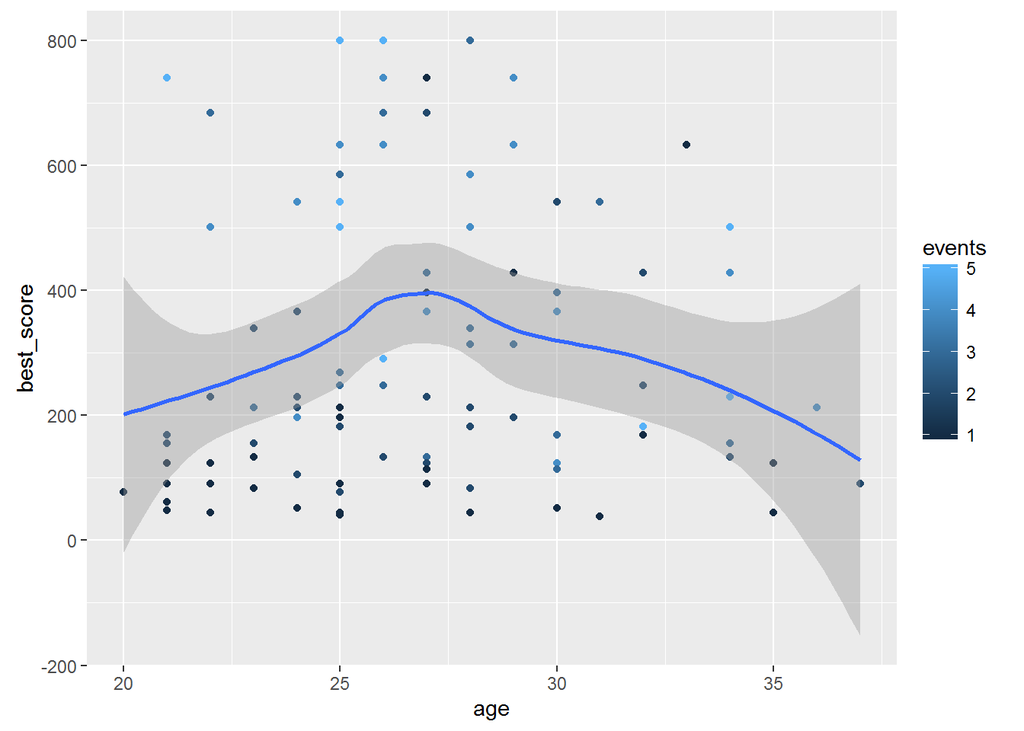

```r
ggplot(tri_small, aes(age, best_score, color = events)) +
  geom_point() +
  geom_smooth()
```